# Palmer Penguins

Ishika Saha 2024-12-26

# R Markdown

This is an R Markdown document enlighting you about some of the basic features of ggplot, which is an essential data visualization tool. Markdown is a simple formatting syntax for authoring HTML, PDF, and MS Word documents.

##Setting up my environment

First we need to install the packages and here we are working with Palmer penguins dataset:

```r
#install.packages("ggplot2")
#install.packages("palmerpenguins")
```

Next we load the packages to our workspace:

```r
library(ggplot2)
library(palmerpenguins)
```

In order to upload the dataframe and view it:

```r
data(penguins)
View(penguins)
```

If we want to find a relationship between flipper length and body mass of the penguins we run the following code:

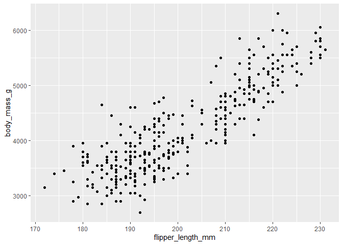

```r
ggplot(data = penguins) + geom_point(mapping = aes(x=flipper_length_mm,y=body_mass_g))
```

The **ggplot()** function creates a coordinate system that you can add layers to. The first argument of the ggplot() function is the dataset to use in the plot. In this case, it’s “penguins.”Then, you add a **+** symbol to add a new layer to your plot. The **geom_point()** function uses points to create **scatterplots**.Each geom function in ggplot2 takes a mapping argument. This defines how variables in your dataset are mapped to visual properties. The mapping argument is always paired with the aes() function. The x and y arguments of the aes() function specify which variables to map to the x-axis and the y-axis of the coordinate system. In this case, you want to map the variable **“flipper_length_mm”** to the **x-axis**, and the variable **“body_mass_g”** to the **y-axis**.

##AESTHETICS

Now we are adding different *Aesthetic Features* like colour, shape, size, alpha and many more:

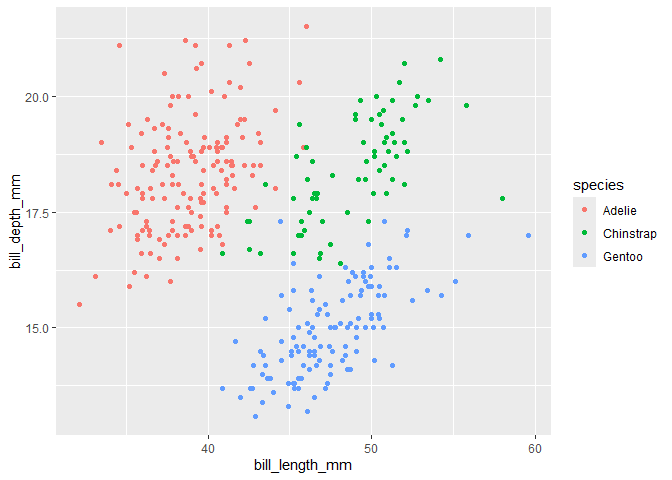

```r
ggplot(data=penguins) + geom_point(mapping = aes(x=bill_length_mm, y=bill_depth_mm, color = species))   #diff color is added for every different specie
```

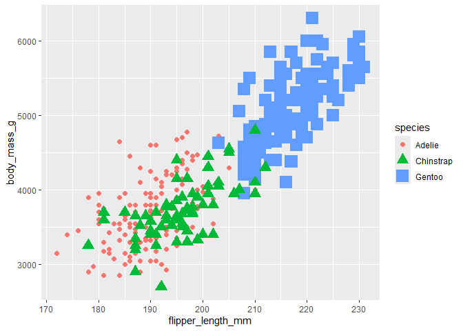

```r
ggplot(data = penguins) + geom_point(mapping = aes(x=flipper_length_mm,y=body_mass_g, shape = species, color = species, size = species))   #diff shape is added to evry different specie
```

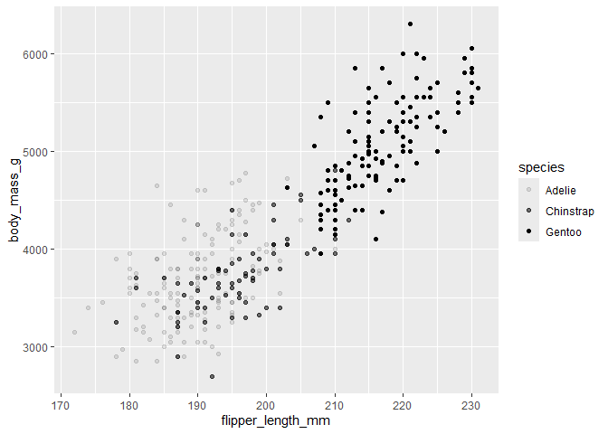

```r
ggplot(data = penguins) + geom_point(mapping = aes(x=flipper_length_mm,y=body_mass_g, alpha = species)) #color density varies from one specie to another by alpha aes
```

To add a colour or aesthetic to overall plot irrespective of any particular variable we write that outside the parethesis of aes()

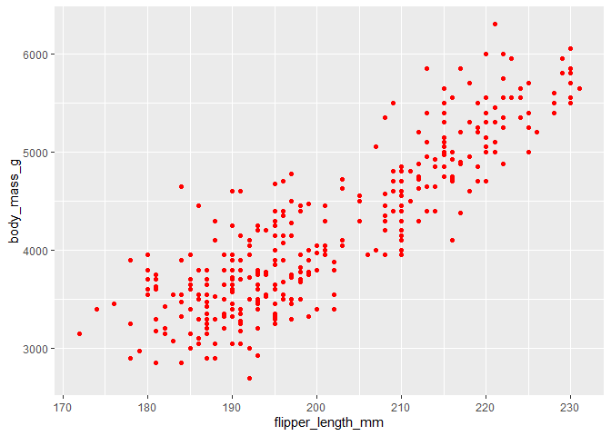

```r
ggplot(data = penguins) + geom_point(mapping = aes(x=flipper_length_mm,y=body_mass_g), colour = "red")
```

To create a trend line so that we can easily identify any trend if its not normally visible we use geom_smooth()

```
## Warning: Removed 2 rows containing non-finite outside the scale range
## (`stat_smooth()`).

## Warning: Removed 2 rows containing missing values or values outside the scale range
## (`geom_point()`).
```

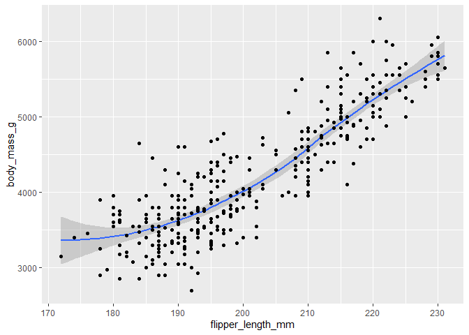

```r
ggplot(data = penguins) + geom_smooth(mapping = aes(x=flipper_length_mm,y=body_mass_g)) +
  geom_point(mapping = aes(x = flipper_length_mm,y=body_mass_g))
```

. A *line type* aesthetic is added here to assign different line types to every specie.

```
## Warning: Removed 2 rows containing non-finite outside the scale range
## (`stat_smooth()`).
```

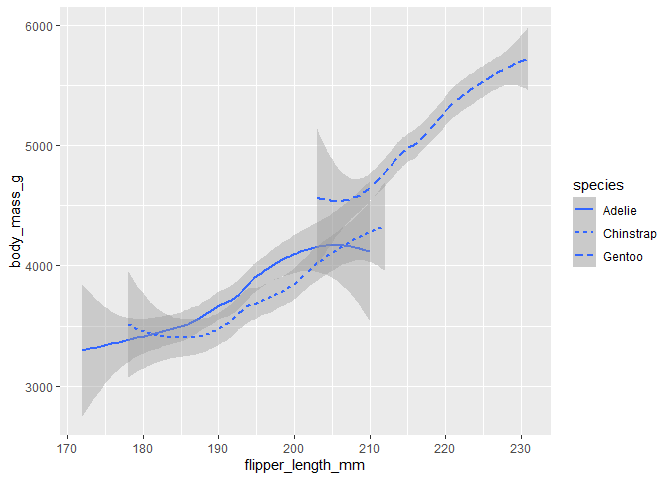

```r
ggplot(data = penguins) +
  geom_smooth(mapping = aes(x = flipper_length_mm,y=body_mass_g,linetype=species))
```

To view every data point clearly we use geom_jitter() which is just an advanced scatterplot.

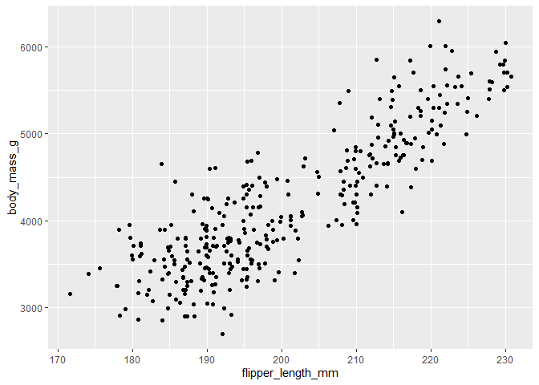

```r
ggplot(data = penguins) +
  geom_jitter(mapping = aes(x = flipper_length_mm,y=body_mass_g))
```

##FACETS

The **facet_wrap** is a function separating and distributing the independent data within the plot.

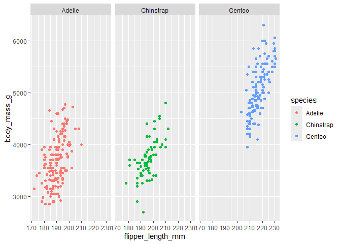

```r
ggplot(data = penguins) + geom_point(mapping = aes(x=flipper_length_mm,y=body_mass_g,colour = species))+
  facet_wrap(~species)
```

Here the independent data is species which is always written in the right of tilde(~) operator.

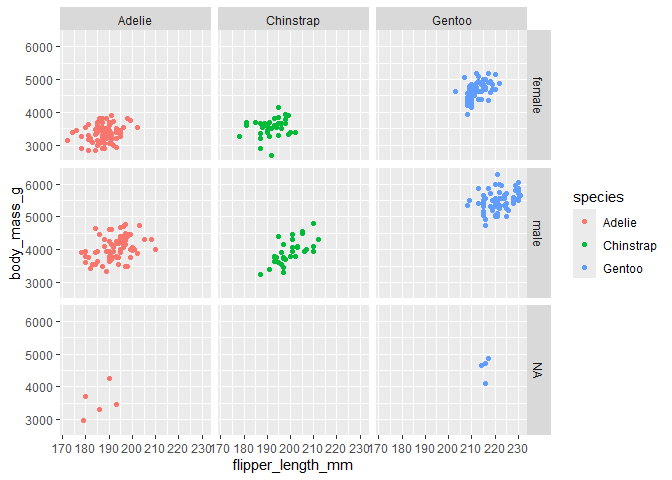

```r
ggplot(data = penguins) + geom_point(mapping = aes(x=flipper_length_mm,y=body_mass_g,colour = species))+
  facet_grid(sex~species)
```

**facet_grid** can take 2 var as input with a (~) in between them. This creates a grid like plot where sex is represented horizontally and species vertically, just like a matrix. But it can also take one input var then it will work the same as wrap.

##ANNOTATIONS

It’s used to add labels(labs) that include title, subtitle, caption, and also any additional information inside the plot. To add text inside the plot we use annotate(), which further has the type of information we want to include, the x coordinate(distance from the x-axis),y coordinate, and the label i.e, the text, color, style, size, angle, etc.

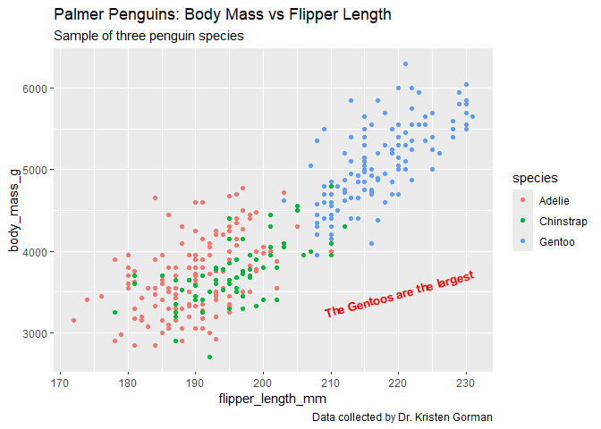

```r
ggplot(data = penguins) + geom_point(mapping = aes(x = flipper_length_mm, y = body_mass_g, colour = species))+
  labs(title = "Palmer Penguins: Body Mass vs Flipper Length", subtitle = "Sample of three penguin species", caption = "Data collected by Dr. Kristen Gorman")+
  annotate("text", x=220,y=3500,label="The Gentoos are the largest",color="red",fontface="bold",size=3.5,angle=15)
```

###Alternate way

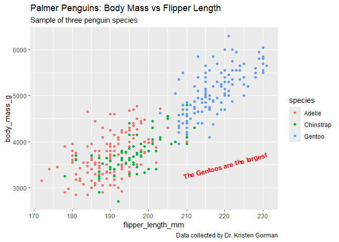

```r
p <- ggplot(data = penguins) + geom_point(mapping = aes(x = flipper_length_mm, y = body_mass_g, colour = species))+
  labs(title = "Palmer Penguins: Body Mass vs Flipper Length", subtitle = "Sample of three penguin species", caption = "Data collected by Dr. Kristen Gorman")
p + annotate("text", x=220,y=3500,label="The Gentoos are the largest",color="red",fontface="bold",size=3.5,angle=15)
```

Now we can save the plot in form of .jpg or .png file:

```r
ggsave('PalmerPennguin plot.jpg')
```

```
## Warning: Removed 2 rows containing missing values or values outside the scale range
## (`geom_point()`).
```